# Fungal Communities associated with the Coffee Rust

Ariel Torres

2026-07-16

## Overview

This project characterizes the fungal community associated with coffee leaf rust infection across different coffee varieties, culture-independent approaches. Particular attention is given to leaf endophytes, given their potential to reduce disease severity in agricultural systems. The ITS2 sequences were obtained and performed an analisis in QIIME2, but Specifically, this analysis asks: how does the fungal community, including endophyte composition and diversity, vary with rust coffee variety? To answer this, we apply statistical analyses including PERMANOVA, Kruskal-Wallis and Dunn’s post-hoc tests, and alpha and beta diversity indices.

## Setup

```r
## =========================================================
## SETUP: package installation (CRAN, Bioconductor, GitHub)
## =========================================================

## --- 0. Tools needed first ---
if (!requireNamespace("devtools", quietly = TRUE)) install.packages("devtools")
if (!requireNamespace("remotes", quietly = TRUE)) install.packages("remotes")
if (!requireNamespace("BiocManager", quietly = TRUE)) install.packages("BiocManager")

## --- 1. Package lists ---
cran_packages <- c("bookdown", "knitr", "tidyverse", "plyr", "gridExtra",
                    "kableExtra", "xtable", "ggpubr", "ggplot2",
                    "RColorBrewer", "openxlsx", "xlsx", "microViz", "ComplexHeatmap", "FSA", "vegan")  # xlsx needs Java; openxlsx doesn't

bioc_packages <- c("phyloseq", "dada2", "DECIPHER", "phangorn",
                    "DESeq2", "microbiome", "philr")

# source ("user/repo") and package name must stay aligned by index
git_source   <- c("gmteunisse/Fantaxtic",
                   "gmteunisse/ggnested",
                   "MadsAlbertsen/ampvis2",
                   "opisthokonta/tsnemicrobiota")
git_packages <- c("fantaxtic", "ggnested", "ampvis2", "tsnemicrobiota")

## --- 2. Install CRAN packages ---
.inst <- cran_packages %in% rownames(installed.packages())
if (any(!.inst)) install.packages(cran_packages[!.inst])

## --- 3. Install Bioconductor packages ---
.inst <- bioc_packages %in% rownames(installed.packages())
if (any(!.inst)) BiocManager::install(bioc_packages[!.inst], update = FALSE, ask = FALSE)

## --- 4. Install GitHub packages (only what's missing) ---
.inst <- git_packages %in% rownames(installed.packages())
if (any(!.inst)) {
  for (src in git_source[!.inst]) {
    remotes::install_github(src)
  }
}

## --- 5. Load all packages ---
all_packages <- c(cran_packages, bioc_packages, git_packages)
invisible(lapply(all_packages, function(pkg) {
  library(pkg, character.only = TRUE)
}))
```

```r
# Global options, seeds, constants
set.seed(42)
```

## Load Data

```r
setwd("~/Downloads")

getwd()

list.files()
```

## Required Datasets for QIIME2 Metabarcoding Analysis

To perform metabarcoding analysis in QIIME2, three essential datasets must be downloaded/exported beforehand:

1. **Abundance data** – The feature/OTU table containing read counts (abundances) of each amplicon sequence variant (ASV) or operational taxonomic unit (OTU) across all samples. This is typically exported from a `csv` artifact.
2. **Taxonomy data** – The taxonomic classification assigned to each feature (ASV/OTU), usually generated through a classifier (e.g., `classify-sklearn` or `classify-consensus-vsearch`) and exported from a `tsv` artifact. This links each sequence variant to its taxonomic identity (domain, phylum, class, order, family, genus, species).
3. **Metadata** – The sample metadata file (usually a `.tsv`) describing the experimental design, including sample IDs and associated variables (e.g., treatment groups, collection site, timepoint, environmental parameters). This is essential for linking abundance and taxonomy data to sample-level context for downstream statistical and ecological analyses.

Together, these three datasets form the foundation for downstream analyses such as diversity metrics, differential abundance testing, and taxonomic visualization.

```r
## =========================================================
## Load: Abundance Data
## =========================================================

df_count <- read.xlsx2("abundanceITS2.xlsx", sheetIndex = 1, row.names = 1)
df_count <- df_count %>% mutate_if(is.character, as.numeric) # to have only numeric values
sapply(df_count, class)
```

```
##     Hv01p     Hv02p     Hv04p     Hv05p     Hv06p     Hv07p     Hv08p     Hv09p
## "numeric" "numeric" "numeric" "numeric" "numeric" "numeric" "numeric" "numeric"
##     Hv10p     Hv12p     Hv13p     Hv14p     Hv15p     Hv16p     Hv17p     Hv18p
## "numeric" "numeric" "numeric" "numeric" "numeric" "numeric" "numeric" "numeric"
##     Hv19p     Hv20p     Hv21p
## "numeric" "numeric" "numeric"
```

```r
## =========================================================
## Load: Taxonomy & Metadata
## =========================================================

#Import taxonomy dataset
df_tax <- read.table('taxonomy.tsv', row.names=1, header=TRUE, sep='\t')


#Import metadata
df_meta <-  read.table('metadata.tsv', row.names=1, header=TRUE, sep='\t')
```

## What is Phyloseq?

**Phyloseq** is an R package designed for importing, storing, analyzing, and graphically displaying complex microbiome/metabarcoding data (e.g., from QIIME2, mothur, or DADA2). It integrates multiple data types—abundance tables, taxonomy, sample metadata, and phylogenetic trees—into a single, unified object (a `phyloseq` object), making it easier to manipulate and analyze all components together without losing the links between them.

A `phyloseq` object typically combines: - **`otu_table`** – abundance/count data (samples × taxa) - **`tax_table`** – taxonomic classifications for each feature - **`sample_data`** – sample-level metadata - **`phy_tree`** (optional) – phylogenetic tree of the features

This structure allows downstream analyses (diversity metrics, ordination, differential abundance, visualization) to be performed consistently across all data layers.

```r
#Create matrix of the AVSs and taxa
m_count <- as.matrix(df_count) # Converts the abundance data frame (features × samples) into a matrix
m_tax <- as.matrix(df_tax) # Converts the taxonomy data frame into a matrix

#Create table components
OTU <- otu_table(m_count, taxa_are_rows=TRUE)
TAX <- tax_table(m_tax)
MD <- sample_data(df_meta)

#Create a Phyloseq artifact
physeq = phyloseq(OTU, TAX,MD)

#Normalization
total = median(colSums(df_count)) # Calculates the median total read count (sequencing depth) across all samples, used as a common target depth for normalization.

myFunction = function(x, t=total) round(t * (x / sum(x)))
# Defines a custom normalization function that rescales each sample's counts proportionally so its total equals `total` #(a form of median sequencing depth normalization, similar to relative abundance scaling).

# Applies the normalization function to every sample in the `phyloseq` object, producing a new normalized object (`physeq_norm`) where all samples have comparable total abundances.
physeq_norm = transform_sample_counts(physeq, myFunction)

str(physeq_norm)
```

```
## Formal class 'phyloseq' [package "phyloseq"] with 5 slots
##   ..@ otu_table:Formal class 'otu_table' [package "phyloseq"] with 2 slots
##   .. .. ..@ .Data        : num [1:1806, 1:19] 25720 9123 216 270 509 ...
##   .. .. .. ..- attr(*, "dimnames")=List of 2
##   .. .. .. .. ..$ : chr [1:1806] "3438a8987248dbba5d9169b216b11a6a" "ed73024bff1582f5dcc919dde6392665" "7e2c9bb1a431f3041f0409544a212dcf" "c2bb931b259e17d65ee1955ff2c42aaf" ...
##   .. .. .. .. ..$ : chr [1:19] "Hv01p" "Hv02p" "Hv04p" "Hv05p" ...
##   .. .. ..@ taxa_are_rows: logi TRUE
##   .. .. ..$ dim     : int [1:2] 1806 19
##   .. .. ..$ dimnames:List of 2
##   .. .. .. ..$ : chr [1:1806] "3438a8987248dbba5d9169b216b11a6a" "ed73024bff1582f5dcc919dde6392665" "7e2c9bb1a431f3041f0409544a212dcf" "c2bb931b259e17d65ee1955ff2c42aaf" ...
##   .. .. .. ..$ : chr [1:19] "Hv01p" "Hv02p" "Hv04p" "Hv05p" ...
##   ..@ tax_table:Formal class 'taxonomyTable' [package "phyloseq"] with 1 slot
##   .. .. ..@ .Data: chr [1:1806, 1:8] "Fungi" "Fungi" "Fungi" "Fungi" ...
##   .. .. .. ..- attr(*, "dimnames")=List of 2
##   .. .. .. .. ..$ : chr [1:1806] "3438a8987248dbba5d9169b216b11a6a" "ed73024bff1582f5dcc919dde6392665" "7e2c9bb1a431f3041f0409544a212dcf" "c2bb931b259e17d65ee1955ff2c42aaf" ...
##   .. .. .. .. ..$ : chr [1:8] "Kingdom" "Phylum" "Class" "Order" ...
##   .. .. ..$ dim     : int [1:2] 1806 8
##   .. .. ..$ dimnames:List of 2
##   .. .. .. ..$ : chr [1:1806] "3438a8987248dbba5d9169b216b11a6a" "ed73024bff1582f5dcc919dde6392665" "7e2c9bb1a431f3041f0409544a212dcf" "c2bb931b259e17d65ee1955ff2c42aaf" ...
##   .. .. .. ..$ : chr [1:8] "Kingdom" "Phylum" "Class" "Order" ...
##   ..@ sam_data :'data.frame':    19 obs. of  5 variables:
## Formal class 'sample_data' [package "phyloseq"] with 4 slots
##   .. .. ..@ .Data    :List of 5
##   .. .. .. ..$ : chr [1:19] "1_5_T_FEIMA_Catuai_m" "2_5_T_FEIMA_Catuai_c" "4_6_T_CATIE_BA" "5_6_T_CATIE_Geisha" ...
##   .. .. .. ..$ : chr [1:19] "Turrialba" "Turrialba" "Turrialba" "Turrialba" ...
##   .. .. .. ..$ : chr [1:19] "FEIMA_mutantes catuaÂ¡" "FEIMA_mutantes_control" "CATIE" "CATIE" ...
##   .. .. .. ..$ : chr [1:19] "Catuai_m" "Catuai_Ctrl" "BA" "Geisha" ...
##   .. .. .. ..$ : chr [1:19] "Hv01p" "Hv02p" "Hv04p" "Hv05p" ...
##   .. .. ..@ names    : chr [1:5] "origin" "region" "farm" "var" ...
##   .. .. ..@ row.names: chr [1:19] "Hv01p" "Hv02p" "Hv04p" "Hv05p" ...
##   .. .. ..@ .S3Class : chr "data.frame"
##   ..@ phy_tree : NULL
##   ..@ refseq   : NULL
```

## Why Normalize This Way (and Caveats)

### The rationale

In metabarcoding data, different samples are sequenced to different depths (i.e., some samples get many more total reads than others just due to technical variation in sequencing, not biology). This makes raw counts incomparable across samples a sample with more reads will appear to have “more” of every taxon simply because it was sequenced deeper, not because it’s biologically richer or more abundant.

The code addresses this using **median sequencing depth normalization**: - It calculates the **median total read count** across all samples (`total`). - It then rescales every sample’s counts proportionally (`x / sum(x)`) and multiplies by that median total, so each sample ends up with a comparable total abundance. - This is conceptually similar to converting to relative abundances, but rescaled back to a count-like value (rounded), which keeps the data structure compatible with functions expecting integer-like counts.

### Caveats

1. **Not a true count-based normalization** — Unlike methods such as **DESeq2** (median-of-ratios) or **CSS (Cumulative Sum Scaling, via `metagenomeSeq`)**, this approach doesn’t model the underlying count distribution or account for compositional effects. It’s a simpler, more heuristic scaling.
2. **Alternative to rarefaction, but with trade-offs** — This method avoids discarding data (unlike rarefaction, which subsamples down to the lowest sequencing depth and throws away reads). However, rarefaction is still preferred by some researchers for diversity analyses because it standardizes sampling effort more rigorously, even though it sacrifices data.
3. **Rounding introduces small artifacts** — Using `round()` after scaling can create minor inaccuracies, especially for low-abundance taxa (values close to zero may round up/down inconsistently).
4. **Not ideal for differential abundance testing** — For statistical testing of taxon abundance differences between groups, dedicated tools like **DESeq2**, **ANCOM-BC**, or **corncob** are generally recommended over this type of manual normalization, since they better handle compositionality and variance structure inherent to microbiome count data.
5. **Zeros remain zeros** — Since the transformation is proportional, any taxa with zero counts in a sample remain zero after normalization (no imputation), which is expected behavior but worth noting when downstream methods are sensitive to sparsity.

### When this approach is reasonable

This median-based scaling is a quick, interpretable way to make abundances more comparable across samples for visualization (e.g., bar plots, heatmaps) or exploratory analysis. For more rigorous statistical comparisons, it’s best to pair this with (or replace it by) dedicated normalization methods designed for compositional microbiome data.

Before starting plotting first define a theme, that is ready to be included in a scientific paper

```r
mytheme <-
  theme(
    axis.ticks = element_blank(),
    panel.grid.minor = element_blank(),
    panel.grid.major = element_blank(),
    panel.background = element_blank(),
    legend.position = "right",
    legend.title = element_text(
      colour = "black",
      size = rel(1.5),
      family = "Times New Roman"
    ),
    plot.title = element_text(
      colour = "black",
      face = "bold",
      size = rel(1.7),
      hjust = 0.5,
      family = "Times New Roman"))

mytheme3 <-
  theme(
    panel.grid.minor = element_blank(),
    panel.grid.major = element_blank(),
    panel.background = element_blank(),
    legend.position = "right",
    legend.title = element_text(
      colour = "black",
      size = rel(1.5),
      family = "Times New Roman"
    ),
    plot.title = element_text(
      colour = "black",
      face = "bold",
      size = rel(1.7),
      hjust = 0.5,
      family = "Times New Roman"))

mytheme2 <-  theme ( axis.line = element_line(size = 1, colour = "black"),
                     axis.ticks = element_blank(),
                     panel.grid.major = element_line(colour = "grey", size = rel(0.1)),
                     panel.grid.minor = element_line(colour = "grey", size = rel(0.1)),
                     panel.background = element_blank(),
                     #legend.key = element_rect(fill = "whitesmoke"),
                     legend.title = element_text(
                       colour = "black",
                       size = rel(1.5),
                       family = "Times New Roman"
                     ),
                     plot.title = element_text(
                       colour = "black",
                       face = "bold",
                       size = rel(1.7),
                       hjust = 0.5,
                       family = "Times New Roman"))
```

## Exploratory Analysis

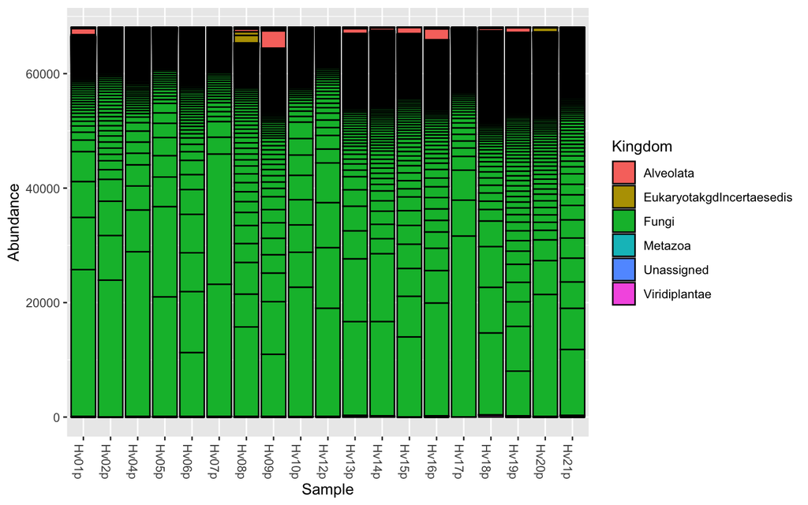

```r
# We can plot the whole artifact, this is to see what we are working with
plot_bar(physeq_norm, fill = "Kingdom")
```

We can catch that in the samples we have different kinds of organisms. Since we extracted DNA from leaves, is expected to have the Plant DNA amplification and other organisms inhabiting the leaf. So, we need to filter this dataset to isolate the fungal communities.

```r
fungi_physeq_norm <- subset_taxa(physeq_norm, Kingdom %in% ("Fungi")) #selecting only the Fungi
fungi_physeq_norm <- subset_taxa(physeq_norm, !(Kingdom %in% c("Alveolata", "EukaryotakgdIncertaesedis","Unassigned",
                                                              "Viridiplantae", "Metazoa"))) #excluding the other organisms

sample_data(fungi_physeq_norm)
```

```
##                                          origin                  region
## Hv01p                      1_5_T_FEIMA_Catuai_m               Turrialba
## Hv02p                      2_5_T_FEIMA_Catuai_c               Turrialba
## Hv04p                            4_6_T_CATIE_BA               Turrialba
## Hv05p                        5_6_T_CATIE_Geisha               Turrialba
## Hv06p                  3_6_VC_Sn Pedro _Caturra            ValleCentral
## Hv07p                    2_6_T_CATIE_5020_catie               Turrialba
## Hv08p                        1_6_T_FEIMA_Catuai               Turrialba
## Hv09p   4_2_CB_Piedra Candela, Sabalito_Caturra                CotoBrus
## Hv10p                10_2_VC_Calle Solis_Catuai            ValleCentral
## Hv12p                     4_3_VC_Sta Ana_Catuai            ValleCentral
## Hv13p                     7_1_PZ_Cajon _Venecia                      PZ
## Hv14p                   5_1_PZ_La Guaria_Catuai                      PZ
## Hv15p                     8_1_PZ_General_Catuai                      PZ
## Hv16p         10_1_T_La Suiza_St_Teresa_Caturra               Turrialba
## Hv17p 6_2_VO_Grecia _PuenteSalas_ElSitio_Catuai ValleCentral_Occidental
## Hv18p      5_2_VO_Naranjo_Grecia_Caturra_Catuai        Valle_Occidental
## Hv19p  9_2_ZS_Corralillo,Cartago_Caturra_Catuai     LosSantos_Turrialba
## Hv20p                      3_3_ZS_Acosta_Catuai               LosSantos
## Hv21p           1_1_CB_Sabalito_Pittier_Caturra                CotoBrus
##                                                farm            var sampleid.1
## Hv01p                        FEIMA_mutantes catuaÂ¡       Catuai_m      Hv01p
## Hv02p                        FEIMA_mutantes_control    Catuai_Ctrl      Hv02p
## Hv04p                                         CATIE             BA      Hv04p
## Hv05p                                         CATIE         Geisha      Hv05p
## Hv06p                                         Yoses        Caturra      Hv06p
## Hv07p                                         CATIE     5020_catie      Hv07p
## Hv08p                                         FEIMA         Catuai      Hv08p
## Hv09p                                 El_Arrempujon        Caturra      Hv09p
## Hv10p                             Teresita _Murillo         Catuai      Hv10p
## Hv12p                                 Victor_Vargas         Catuai      Hv12p
## Hv13p                                 Erick_LopezÂ         Venecia      Hv13p
## Hv14p                                 Edgar Cordero         Catuai      Hv14p
## Hv15p  FloritaMata_Bonita_Ricardo Cordero_LaPalmira         Catuai      Hv15p
## Hv16p                PuebloReal_ManuelAguilarAraya         Caturra      Hv16p
## Hv17p        CarlosSalazar_LaAmada_FranklinMadrigal         Catuai      Hv17p
## Hv18p FranciscoRamirez_VictorEsteller_CarlosSalazar         Varios      Hv18p
## Hv19p            SaelUrena_JustinNavarro_AlexisVega Caturra_Catuai      Hv19p
## Hv20p                               FranciscoQuiros         Catuai      Hv20p
## Hv21p                  RioBrus_CATTICA_RogerNaranjo         Varios      Hv21p
```

```r
head(sample_data(fungi_physeq_norm))
```

```
##                         origin       region                   farm         var
## Hv01p     1_5_T_FEIMA_Catuai_m    Turrialba FEIMA_mutantes catuaÂ¡    Catuai_m
## Hv02p     2_5_T_FEIMA_Catuai_c    Turrialba FEIMA_mutantes_control Catuai_Ctrl
## Hv04p           4_6_T_CATIE_BA    Turrialba                  CATIE          BA
## Hv05p       5_6_T_CATIE_Geisha    Turrialba                  CATIE      Geisha
## Hv06p 3_6_VC_Sn Pedro _Caturra ValleCentral                  Yoses     Caturra
## Hv07p   2_6_T_CATIE_5020_catie    Turrialba                  CATIE  5020_catie
##       sampleid.1
## Hv01p      Hv01p
## Hv02p      Hv02p
## Hv04p      Hv04p
## Hv05p      Hv05p
## Hv06p      Hv06p
## Hv07p      Hv07p
```

```r
## -------------------------------------------------------------
## 2. Set your grouping variable
## -------------------------------------------------------------
GROUP_VAR <- "var"   # <-- change to match the actual column name in df_meta

stopifnot(GROUP_VAR %in% colnames(sample_data(fungi_physeq_norm)))
sample_data(fungi_physeq_norm)[[GROUP_VAR]] <- factor(sample_data(fungi_physeq_norm)[[GROUP_VAR]])
sample_data(physeq)[[GROUP_VAR]]      <- factor(sample_data(physeq)[[GROUP_VAR]])

cat("Tree varieties detected:\n")
```

```
## Tree varieties detected:
```

```r
print(table(sample_data(fungi_physeq_norm)[[GROUP_VAR]]))
```

```
##
##     5020_catie             BA         Catuai    Catuai_Ctrl       Catuai_m
##              1              1              7              1              1
##        Caturra Caturra_Catuai         Geisha         Varios        Venecia
##              3              1              1              2              1
```

```r
## -------------------------------------------------------------
## 3. Basic sanity checks
## -------------------------------------------------------------
fungi_physeq_norm
```

```
## phyloseq-class experiment-level object
## otu_table()   OTU Table:         [ 1707 taxa and 19 samples ]
## sample_data() Sample Data:       [ 19 samples by 5 sample variables ]
## tax_table()   Taxonomy Table:    [ 1707 taxa by 8 taxonomic ranks ]
```

```r
cat("\nSamples with zero total reads (post-norm):", sum(sample_sums(fungi_physeq_norm) == 0), "\n")
```

```
##
## Samples with zero total reads (post-norm): 0
```

```r
cat("Taxa with zero reads across all samples:", sum(taxa_sums(fungi_physeq_norm) == 0), "\n")
```

```
## Taxa with zero reads across all samples: 0
```

```r
cat("Any NA in group variable:", any(is.na(sample_data(fungi_physeq_norm)[[GROUP_VAR]])), "\n")
```

```
## Any NA in group variable: FALSE
```

```r
fungi_physeq_norm <- prune_taxa(taxa_sums(fungi_physeq_norm) > 0, fungi_physeq_norm)
```

## Sequencing depth: raw vs normalized, by tree variety

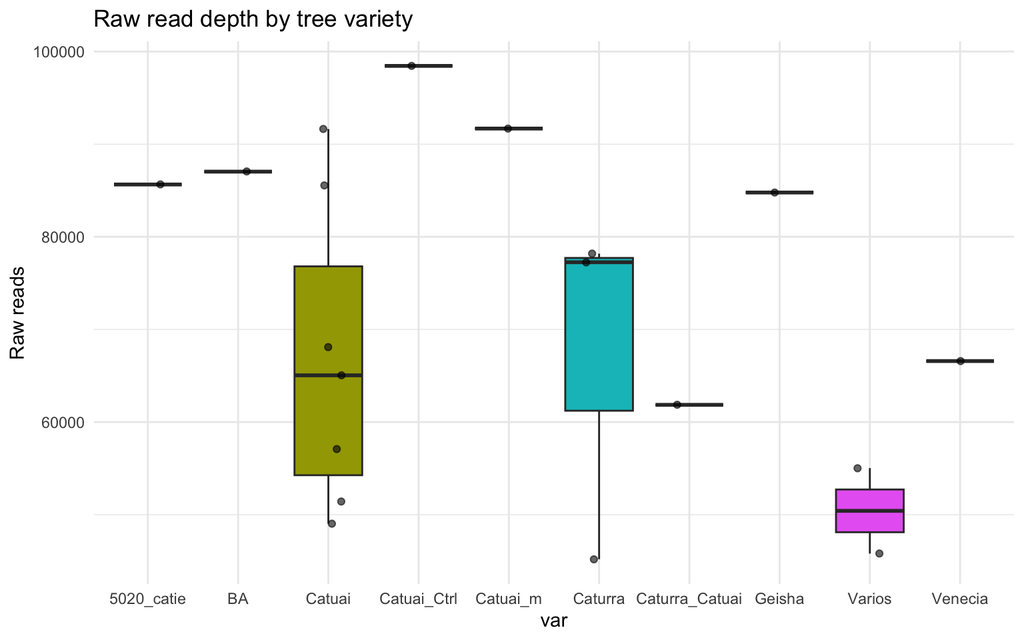

```r
## -------------------------------------------------------------
## 4. Sequencing depth: raw vs normalized, by tree variety
## -------------------------------------------------------------
depth_df <- data.frame(
  Sample    = sample_names(physeq),
  Raw_Reads = sample_sums(physeq),
  Norm_Reads = sample_sums(fungi_physeq_norm),
  Group     = sample_data(physeq)[[GROUP_VAR]]
)

p_depth_raw <- ggplot(depth_df, aes(x = Group, y = Raw_Reads, fill = Group)) +
  geom_boxplot(outlier.shape = NA) +
  geom_jitter(width = 0.15, alpha = 0.6) +
  theme_minimal() + theme(mytheme, legend.position = "none") +
  labs(title = "Raw read depth by tree variety", x = GROUP_VAR, y = "Raw reads")

p_depth_norm <- ggplot(depth_df, aes(x = Group, y = Norm_Reads, fill = Group)) +
  geom_boxplot(outlier.shape = NA) +
  geom_jitter(width = 0.15, alpha = 0.6) +
  theme_minimal() + theme(mytheme, legend.position = "none") +
  labs(title = "Normalized read depth by tree variety", x = GROUP_VAR, y = "Normalized reads")

print(p_depth_raw)
```

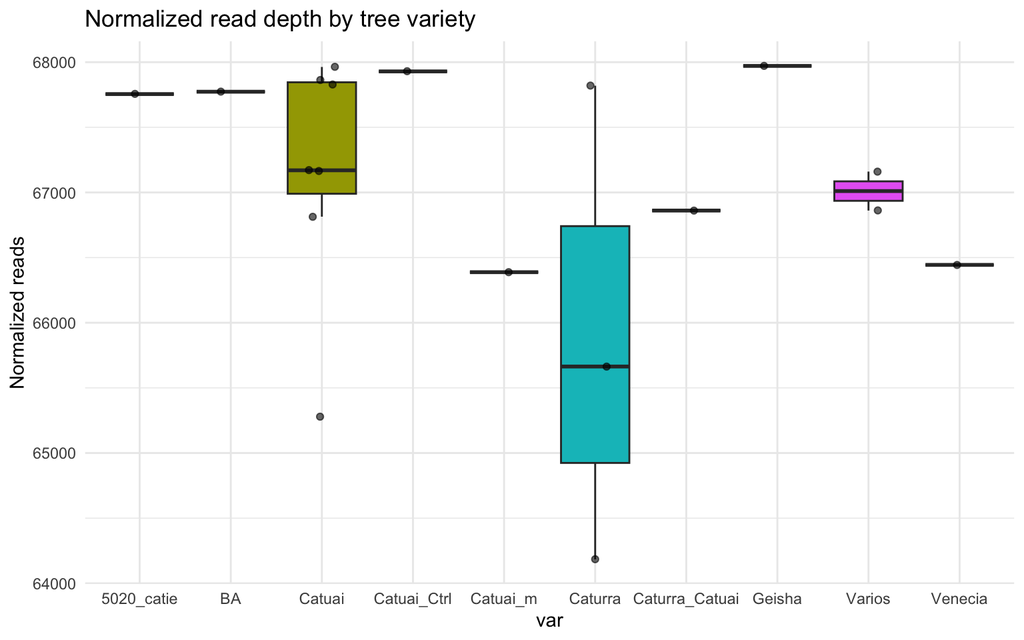

```r
print(p_depth_norm)
```

```r
summary(depth_df$Raw_Reads)
```

```
##    Min. 1st Qu.  Median    Mean 3rd Qu.    Max.
##   45199   56060   68090   70810   85586   98448
```

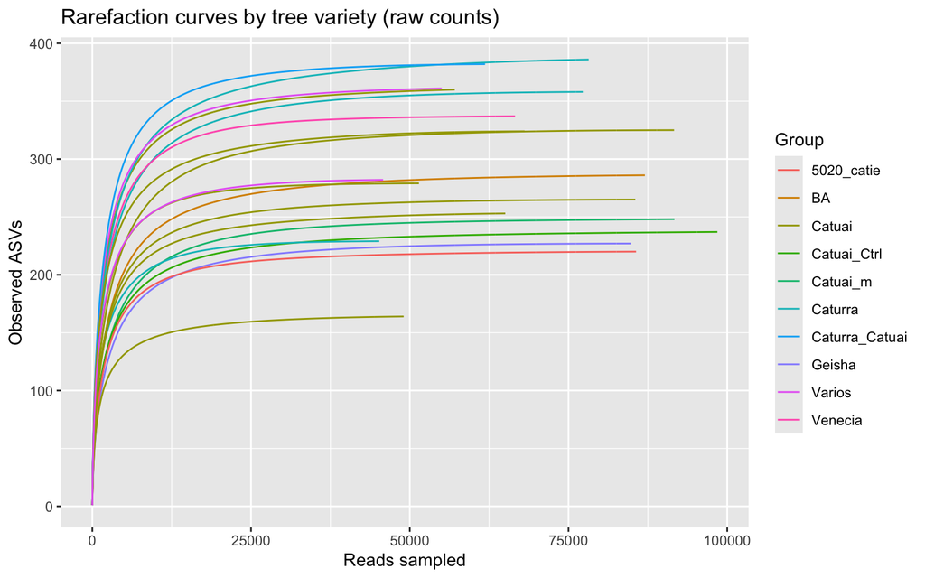

```r
## -------------------------------------------------------------
## 5. Rarefaction curves (on RAW counts, colored by variety)
##    Rarefaction should always use raw counts, not normalized ones
## -------------------------------------------------------------
otu_mat <- as(otu_table(physeq), "matrix")
if (taxa_are_rows(physeq)) otu_mat <- t(otu_mat)

rare_data <- vegan::rarecurve(otu_mat, step = 50, tidy = TRUE)
rare_data <- rare_data %>% left_join(depth_df, by = c("Site" = "Sample"))

p_rare <- ggplot(rare_data, aes(x = Sample, y = Species, group = Site, color = Group)) +
  geom_line() +
  theme(mytheme) +
  labs(title = "Rarefaction curves by tree variety (raw counts)",
       x = "Reads sampled", y = "Observed ASVs")
print(p_rare)
```

We can see the composition at the phylum level for the samples. As expected the Ascomycetes are the most abudant fungi in the samples

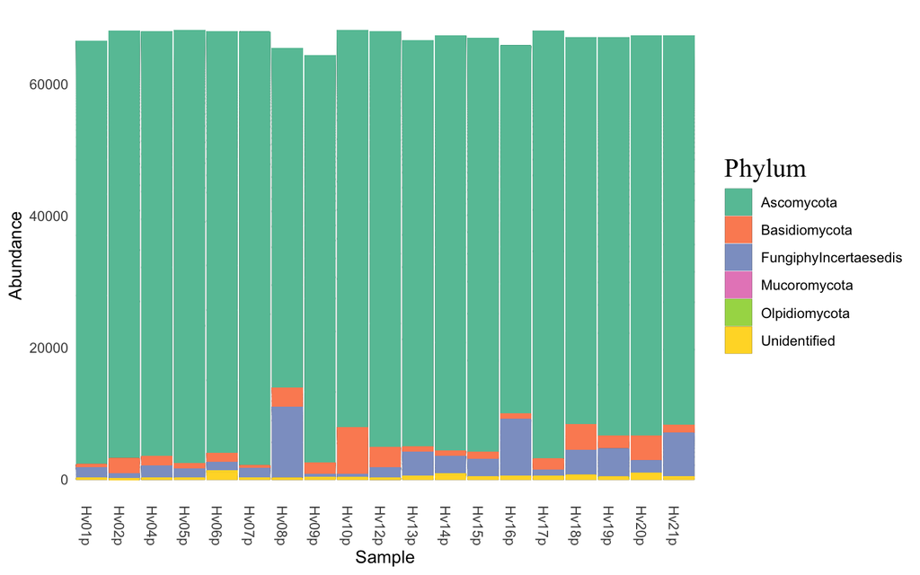

```r
plot_bar(fungi_physeq_norm, fill = "Phylum") + geom_bar(aes(color=Phylum, fill= Phylum), stat="identity", position="stack") + mytheme + scale_colour_brewer(palette = "Set2")+scale_fill_brewer(palette = "Set2")
```

We can plot this same plot to inspect further the relative abundance of phylum by variety. You can explore at other level, by changing the “TAX_RANK” by “Class”.

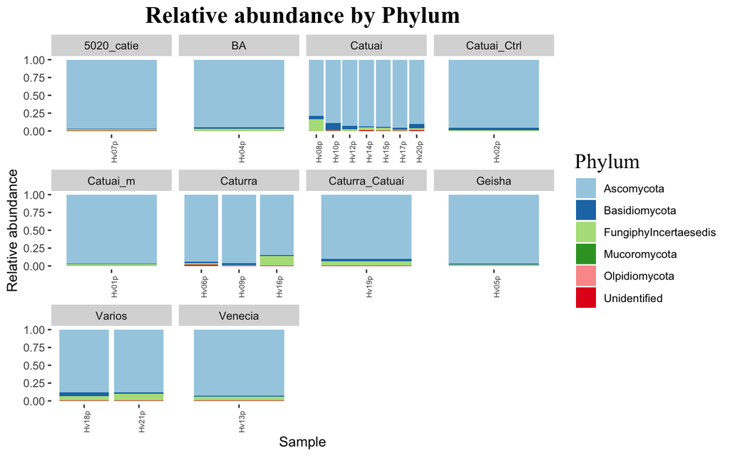

```r
TAX_RANK <- "Phylum"  # <-- adjust to an actual column name from the line above

ps_rel <- transform_sample_counts(fungi_physeq_norm, function(x) x / sum(x))
ps_rank <- tax_glom(ps_rel, taxrank = TAX_RANK, NArm = FALSE)
comp_df <- psmelt(ps_rank)

p_comp <- ggplot(comp_df, aes(x = Sample, y = Abundance, fill = .data[[TAX_RANK]])) +
  geom_col() +
  facet_wrap(as.formula(paste0("~", GROUP_VAR)), scales = "free_x") +
  mytheme3 +
  theme(axis.text.x = element_text(angle = 90, hjust = 1, size = 6)) +
  scale_fill_brewer(palette = "Paired") +
  labs(title = paste("Relative abundance by", TAX_RANK), y = "Relative abundance")
print(p_comp)
```

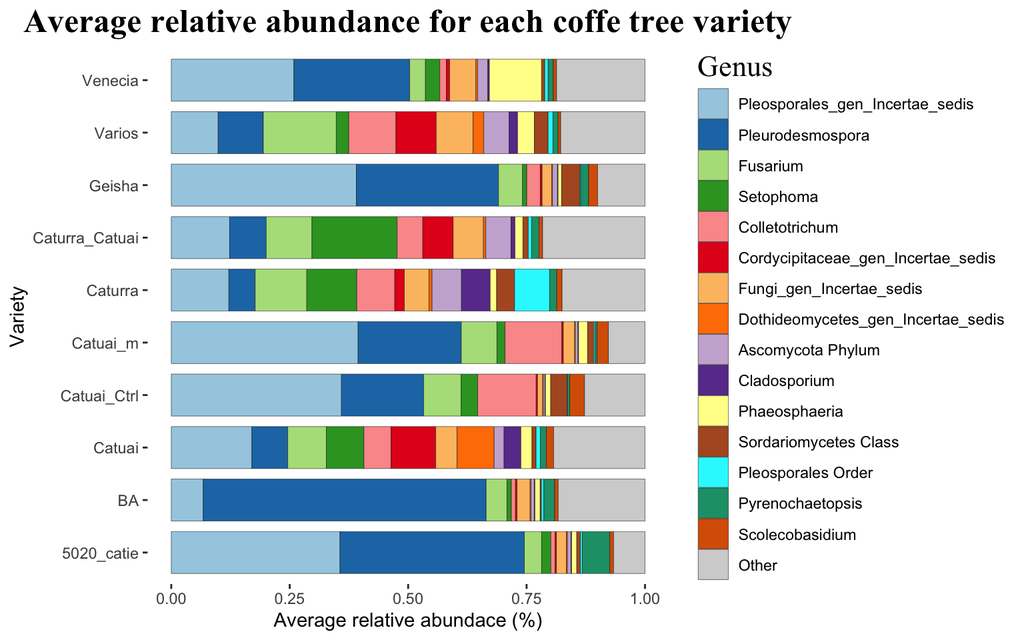

```r
genus_var_plot<-fungi_physeq_norm %>% tax_fix(unknowns = c("Unidentified")) %>% #
  phyloseq::merge_samples(group = "var") %>%
  comp_barplot(tax_level = "Genus", n_taxa = 15, sample_order = c("5020_catie", "BA","Catuai", "Catuai_Ctrl","Catuai_m",
                                                                   "Caturra", "Caturra_Catuai",
                                                                   "Geisha", "Varios","Venecia"), bar_width = 0.8) +
  coord_flip() + ylab ("Average relative abundace (%)") + xlab("Variety") + ggtitle("Average relative abundance for each coffe tree variety") + labs(fill = "Genus") + mytheme3

genus_var_plot
```

```r
# ggsave("genus_var_plot.png", plot = genus_var_plot, width = 15, height = 10, dpi = 600)
# in case you wan to save this chart for publishing
```

To examine fungal community composition at the class level, we generated a heat map of the relative abundances of fungal classes across all samples, accompanied by the prevalence of each class. The heat map highlights differences in the relative abundance of fungal classes among samples, while the prevalence summarizes how consistently each class is detected across samples. Together, these visualizations allow us to assess whether fungal communities exhibit consistent class-level patterns associated with each variety and to distinguish dominant but infrequent taxa from taxa that are widespread across samples.

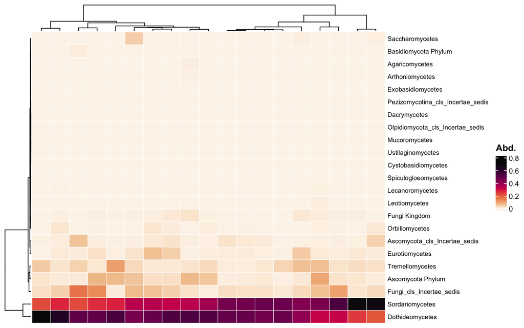

```r
#First we define the level we want to examine at with rank="Class"
fungi_physeq_norm %>% tax_fix(unknowns = c("Unidentified")) %>%
  tax_transform("compositional", rank = "Class") %>%
  comp_heatmap()
```

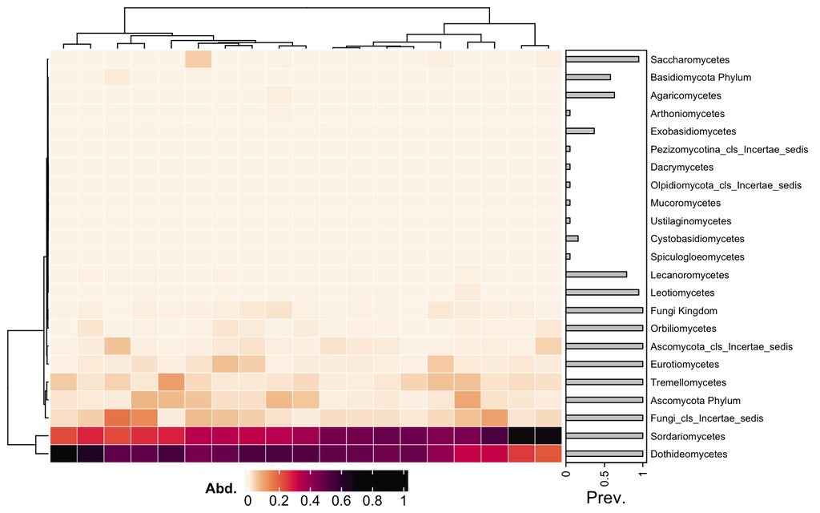

```r
#Relative Abundance and Prevalence of taxa using the complex heatmap library
heat <-fungi_physeq_norm %>% tax_fix(unknowns = c("Unidentified")) %>%
  tax_transform("compositional", rank = "Class") %>%
  comp_heatmap(
    tax_anno = taxAnnotation(
      Prev. = anno_tax_prev(bar_width = 0.3, size = grid::unit(2, "cm")) #prevalence
    ),
    heatmap_legend_param = list(
      at = 0:5 / 5,
      direction = "horizontal", title_position = "leftcenter",
      legend_width = grid::unit(4, "cm"), grid_height = grid::unit(5, "mm")
    )
  )

ComplexHeatmap::draw(
  object = heat, heatmap_legend_side = "bottom",
  adjust_annotation_extension = FALSE
)
```

## Analysis / Modeling

We need to describe the fungal communities in different coffe trees varieties, thus we need to calculate the alfa and beta diversity index

### Alfa diversity

The Observed, Shannon, and Chao1 indices are all measures of alpha diversity, which describes the diversity within a single sample. They each capture a different aspect of the community.

| **Index** | **What it measures** | **Interpretation** |
| --- | --- | --- |
| **Observed** (Observed ASVs/OTUs/Species) | **Richness** | Simply counts the number of taxa detected in a sample. Higher values indicate more taxa are present. It does not consider how abundant each taxon is. |
| **Shannon** | **Richness + Evenness** | Measures both the number of taxa and how evenly individuals are distributed among them. A community with many equally abundant taxa has a higher Shannon index than one dominated by a few taxa. |
| **Chao1** | **Estimated Richness** | Estimates the total number of taxa in a community, accounting for taxa that were likely missed due to undersampling. It is especially influenced by rare taxa (singletons and doubletons). |

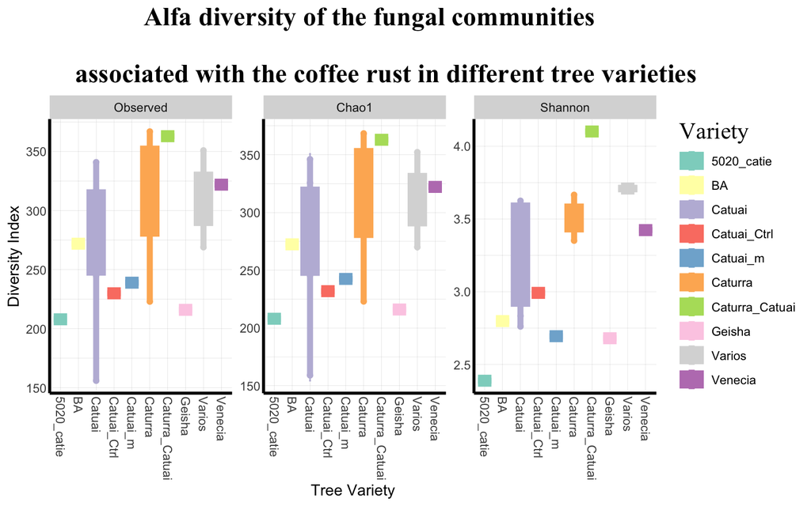

```r
alfa_diversidad_var<-plot_richness(fungi_physeq_norm, color = "var", x = "var", measures = c("Observed", "Chao1", "Shannon")) + geom_boxplot(aes(fill = var), alpha = 1, size = 2) + mytheme2 +
  ggtitle("      Alfa diversity of the fungal communities \n
          associated with the coffee rust in different tree varieties") +
  xlab("Tree Variety") + ylab("Diversity Index") + scale_colour_brewer(palette = "Set3") + scale_fill_brewer(palette = "Set3") + labs(color = "Variety", fill = "Variety") +
  facet_wrap(~variable, scales = "free", labeller = as_labeller(c("Chao1" = "Chao1", "Shannon" = "Shannon", "Observed" = "Observed")))

alfa_diversidad_var
```

Using all three indices provides complementary information:

- Observed richness: How many fungal taxa were detected.
- Chao1: How many fungal taxa are estimated to exist, accounting for rare taxa.
- Shannon: How diverse the community is when considering both the number of taxa and their relative abundances.

```r
head(sample_data(fungi_physeq_norm))
```

```
##                         origin       region                   farm         var
## Hv01p     1_5_T_FEIMA_Catuai_m    Turrialba FEIMA_mutantes catuaÂ¡    Catuai_m
## Hv02p     2_5_T_FEIMA_Catuai_c    Turrialba FEIMA_mutantes_control Catuai_Ctrl
## Hv04p           4_6_T_CATIE_BA    Turrialba                  CATIE          BA
## Hv05p       5_6_T_CATIE_Geisha    Turrialba                  CATIE      Geisha
## Hv06p 3_6_VC_Sn Pedro _Caturra ValleCentral                  Yoses     Caturra
## Hv07p   2_6_T_CATIE_5020_catie    Turrialba                  CATIE  5020_catie
##       sampleid.1
## Hv01p      Hv01p
## Hv02p      Hv02p
## Hv04p      Hv04p
## Hv05p      Hv05p
## Hv06p      Hv06p
## Hv07p      Hv07p
```

```r
alphadiv<-estimate_richness(fungi_physeq_norm, measures = c("Observed", "Chao1", "Shannon"))%>%
  rownames_to_column(var = "sampleid.1") %>%
  left_join(as.data.frame(sample_data(fungi_physeq_norm)), by = "sampleid.1") # join per sample id

head(alphadiv)
```

```
##   sampleid.1 Observed    Chao1   se.chao1  Shannon                   origin
## 1      Hv01p      239 242.5000 3.66211057 2.694547     1_5_T_FEIMA_Catuai_m
## 2      Hv02p      230 231.8750 2.25695758 2.992189     2_5_T_FEIMA_Catuai_c
## 3      Hv04p      272 272.4286 0.83104957 2.798493           4_6_T_CATIE_BA
## 4      Hv05p      216 216.0000 0.03837240 2.680705       5_6_T_CATIE_Geisha
## 5      Hv06p      223 223.0000 0.00000000 3.350791 3_6_VC_Sn Pedro _Caturra
## 6      Hv07p      208 208.0000 0.05542185 2.388992   2_6_T_CATIE_5020_catie
##         region                   farm         var
## 1    Turrialba FEIMA_mutantes catuaÂ¡    Catuai_m
## 2    Turrialba FEIMA_mutantes_control Catuai_Ctrl
## 3    Turrialba                  CATIE          BA
## 4    Turrialba                  CATIE      Geisha
## 5 ValleCentral                  Yoses     Caturra
## 6    Turrialba                  CATIE  5020_catie
```

To evaluate whether fungal diversity differs among varieties, we compared alpha diversity indices using the non-parametric Kruskal–Wallis test. This test is appropriate for comparing diversity indices across multiple groups when the data may not satisfy the assumptions of parametric tests.

```r
#Observed
kruskal.test(Observed ~ var, data = alphadiv)
```

```
##
##  Kruskal-Wallis rank sum test
##
## data:  Observed by var
## Kruskal-Wallis chi-squared = 8.6753, df = 9, p-value = 0.4678
```

```r
#Shannon
kruskal.test(Shannon ~ var, data = alphadiv)
```

```
##
##  Kruskal-Wallis rank sum test
##
## data:  Shannon by var
## Kruskal-Wallis chi-squared = 13.831, df = 9, p-value = 0.1285
```

```r
#Chao1
kruskal.test(Chao1 ~ var, data = alphadiv)
```

```
##
##  Kruskal-Wallis rank sum test
##
## data:  Chao1 by var
## Kruskal-Wallis chi-squared = 8.4602, df = 9, p-value = 0.4885
```

p > 0.05: There is no evidence of a significant difference in alpha diversity among the varieties.

```r
##Observed
dunnO <- dunnTest(Observed ~ var,
                  data=alphadiv,
                  method="bh")
#Shannon
dunnS <- dunnTest(Shannon ~ var,
                  data=alphadiv,
                  method="bh")
```

### Beta diversity

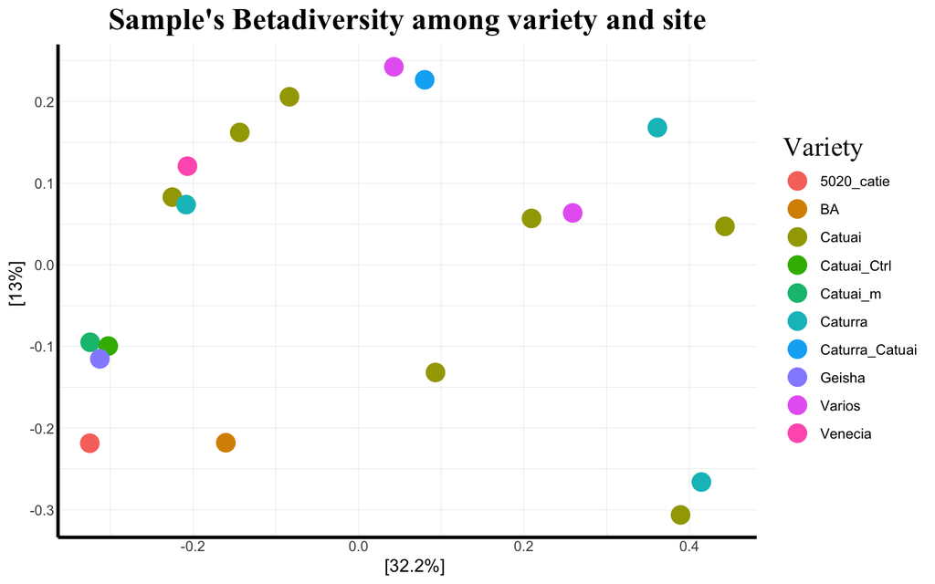

```r
dist_norm <- phyloseq::distance(fungi_physeq_norm, method='bray')
fungi_physeq_norm_var_ord <- ordinate(fungi_physeq_norm, method="PCoA", distance="bray")
diversidad_beta <-plot_ordination(fungi_physeq_norm, fungi_physeq_norm_var_ord, color="var", title = "Sample's Betadiversity among variety and site") + mytheme2 + geom_point(size=5) +
  labs(color = "Variety", fill = "Variety")

diversidad_beta
```

### PERMANOVA

```r
# Calculate bray curtis distance matrix
fungi_physeq_norm_perm <- phyloseq::distance(fungi_physeq_norm, method = "bray")

#Permanova

adonis2(fungi_physeq_norm_perm ~ var, data = df_meta)
```

```
## Permutation test for adonis under reduced model
## Permutation: free
## Number of permutations: 999
##
## adonis2(formula = fungi_physeq_norm_perm ~ var, data = df_meta)
##          Df SumOfSqs      R2      F Pr(>F)
## Model     9   1.9295 0.45452 0.8332  0.839
## Residual  9   2.3156 0.54548
## Total    18   4.2451 1.00000
```

Tree variety does not significantly structure the fungal community composition (PERMANOVA: R² = 0.455, F = 0.833, p = 0.839). Even though the model appears to explain 45% of the variation, this is not statistically distinguishable from chance.

### Principal Component Analysis

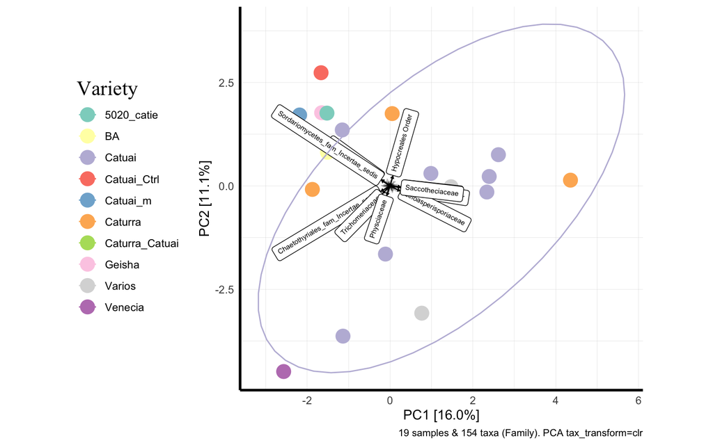

```r
# perform ordination
unconstrained_aitchison_pca <- fungi_physeq_norm %>%
  tax_fix(unknowns = c("Unidentified")) %>%
  tax_agg("Family") %>%
  tax_transform("clr") %>%
  ord_calc()
# ord_calc will automatically infer you want a "PCA" here
# specify explicitly with method = "PCA", or you can pick another method

# create plot
pca_plot <- unconstrained_aitchison_pca %>%
  ord_plot(
    plot_taxa = 1:10, colour = "var", size = 5,
    tax_vec_length = 0.325,
    tax_lab_style = tax_lab_style(max_angle = 90, aspect_ratio = 1),
    auto_caption = 8
  ) +
  labs(colour = "Variety")

# customise plot
customised_plot <- pca_plot +
  stat_ellipse(aes(colour = var), linewidth = 0.5) + # linewidth not size, since ggplot 3.4.0
  scale_colour_brewer(palette = "Set3") +
  theme(legend.position = "left") + mytheme2 +
  coord_fixed(ratio = 1, clip = "off") # makes rotated labels align correctly

# show plot
customised_plot
```

```r
subset_meta <- df_meta[df_meta$var %in% c("Catuai","Caturra","Varios"), ]

subset_physeq <- subset_samples(fungi_physeq_norm, var %in% c("Catuai","Caturra","Varios"))

# Extract distance matrix from your subsetted phyloseq object
subset_dist <- phyloseq::distance(subset_physeq, method = "bray")

adonis2(subset_dist ~ var, data = subset_meta)
```

```
## Permutation test for adonis under reduced model
## Permutation: free
## Number of permutations: 999
##
## adonis2(formula = subset_dist ~ var, data = subset_meta)
##          Df SumOfSqs      R2      F Pr(>F)
## Model     2  0.35748 0.13373 0.6947  0.903
## Residual  9  2.31559 0.86627
## Total    11  2.67307 1.00000
```

The visual clustering you saw on the ordination PCA does not hold up statistically, even when you give it much better power by narrowing to just those 3 varieties.

## Results

Fungal community composition was dominated by Ascomycota across all samples, consistent with typical phyllosphere fungal assemblages. Alpha diversity, assessed using Observed richness, Chao1, and Shannon indices, did not differ significantly among coffee tree varieties (Kruskal–Wallis: Observed χ² = 8.68, df = 9, p = 0.468; Shannon χ² = 13.83, df = 9, p = 0.129; Chao1 χ² = 8.46, df = 9, p = 0.489), indicating that neither taxon richness nor evenness of the fungal community varied consistently with tree variety.Beta diversity, evaluated with Bray–Curtis dissimilarities and visualized by PCoA, showed no clear separation of samples by variety across the full dataset. PERMANOVA confirmed that tree variety did not significantly structure fungal community composition (R² = 0.455, F = 0.833, p = 0.839, n = 19); although the model nominally accounted for 45% of variance, this was not distinguishable from a random permutation-based null.

## Conclusion

Overall, this analysis found no statistically significant association between coffee tree variety and fungal community composition or diversity, at either the alpha or beta level. Apparent visual clustering by variety in ordination space did not hold up under formal testing, even when statistical power was improved by focusing on the best-replicated varieties. These findings suggest that, within this dataset, variety is not a strong driver of fungal community assembly on coffee leaves affected by coffee leaf rust. However, given the limited and uneven replication per variety (n ~ 1–7 samples, with several varieties represented by a single sample), the study is likely underpowered to detect subtle, variety-associated effects, and these results should be interpreted as preliminary. Future work with balanced, larger sample sizes per variety, and potentially incorporating rust severity or leaf endophyte-specific data directly rather than variety alone, would help clarify whether host genotype meaningfully shapes the coffee leaf mycobiome and its interaction with coffee leaf rust.